# ML2 project: breast cancer

Silke Meiner

Rafaela Neff

Proposed data set for the Machine Learning 2 project.

```r
#change working directory to current dir
wd = getwd()
setwd(wd)
#read data
ds <- read.csv('data/data.csv')
dim(ds)
```

```
[1] 569  33
```

```r
str(ds)
```

```
'data.frame':   569 obs. of  33 variables:
 $ id                     : int  842302 842517 84300903 84348301 84358402 843786 844359 84458202 844981 84501001 ...
 $ diagnosis              : Factor w/ 2 levels "B","M": 2 2 2 2 2 2 2 2 2 2 ...
 $ radius_mean            : num  18 20.6 19.7 11.4 20.3 ...
 $ texture_mean           : num  10.4 17.8 21.2 20.4 14.3 ...
 $ perimeter_mean         : num  122.8 132.9 130 77.6 135.1 ...
 $ area_mean              : num  1001 1326 1203 386 1297 ...
 $ smoothness_mean        : num  0.1184 0.0847 0.1096 0.1425 0.1003 ...
 $ compactness_mean       : num  0.2776 0.0786 0.1599 0.2839 0.1328 ...
 $ concavity_mean         : num  0.3001 0.0869 0.1974 0.2414 0.198 ...
 $ concave.points_mean    : num  0.1471 0.0702 0.1279 0.1052 0.1043 ...
 $ symmetry_mean          : num  0.242 0.181 0.207 0.26 0.181 ...
 $ fractal_dimension_mean : num  0.0787 0.0567 0.06 0.0974 0.0588 ...
 $ radius_se              : num  1.095 0.543 0.746 0.496 0.757 ...
 $ texture_se             : num  0.905 0.734 0.787 1.156 0.781 ...
```

[output cut: 19 more lines]

```r
# summary(ds)
```

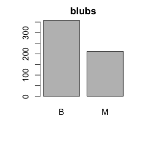

```r
barplot(table(ds$diagnosis), main='blubs')
```

exact numbers

```r
# ds %>% count(diagnosis)
table(ds$diagnosis)
```

```
  B   M
357 212
```

```r
sum(table(ds$diagnosis))
```

```
[1] 569
```

No missing values in the diagnosis, the target value.

Our data is not exactly fully balanced but it could be much worse. We are not in an unbalanced situation as in the usual fraud detection setting.

# Checking for missing data

```r
mice(ds[3:32])
```

[output not shown]

[output cut: 12 more lines]

[output not shown]

I don't understand this output. X is only NA, but diagnosis has no NA.

# Checking for duplicates

```r
duplicated(ds)
```

[output not shown]

There are no duplicates in the data set

# Dataset description

We have a data set of 33 variables, of which

- binary variable diagnosis will be the target variable
- 30 numerical predictor variables / features
- the ID is not a predictor / feature
- X will be removed because it is empty

# Correlation

```r
# install.packages("ggcorrplot")
library(ggcorrplot)
corr <- round(cor(ds[,3:32]), 3)
# ggcorrplot(corr)
ggcorrplot(corr, hc.order = TRUE, outline.col = "white") # uses hierarchical clustering to order variables
```

[output not shown]

Some variables seem highly (pos.) correlated and the number of variables can maybe be reduced.

# Scaling

Our variables are at very different scalings (Größenordnungen).

```r
boxplot(ds[,3:33])
```

[output not shown]

```r
# get a closer look at the variables with a large median

# apply(ds[,3:32], 2, mean)
vars1 <- which(apply(ds[,3:32], 2, mean) > 300)
#vars1
boxplot(ds[,2+vars1]) # 2+ because we initially removed the first 2 variables
```

[output not shown]

```r
# of those the ones with a relatively large median, around 100
# boxplot(ds[,c(5,16,25)])
```

```r
# max values (outliers) below 50
# boxplot(ds[,c(3:4,7:15,17:24,27:33)])
```

and look into the variables with the smallest maximal values

```r
# and the small medians only
# apply(ds[,3:32], 2, mean)
vars1 <- which(apply(ds[,3:32], 2, max) < 0.1)
#vars1
boxplot(ds[,2+vars1]) # 2+ because we initially removed the first 2 variables
```

[output not shown]

We need to scale our data. Though I am not sure how. The variable names like area, mean, se (standard error?!), worst (lowest value? check that for each row the worst values are below the mean? or sometimes above is worse??) seem to suggest something, some meaning. This may be destroyed by normalising / standardising?! Is this relevant?